### Covid e Reeleição

*Você já pensou como a pandemia influenciou a eleição dos candidatos à prefeitura da sua cidade?*

É sabido que o fato de um candidato já estar no cargo aumenta muito a sua probabilidade de ser eleito. Em 2020, 63,73% dos prefeitos que tentaram reeleição tiveram sucesso no primeiro turno (dados do CNM), sendo um resultado recorde desde 1998 (ano que a reeleição começou a valer).

Em um ano de pandemia, será que o número de óbitos por COVID-19 no município influencia na chance de sucesso de reeleição dos prefeitos no Brasil?

Considerando apenas os candidatos que tentaram a reeleição (dados do TSE), é possível realizar uma análise univariada, via regressão logística, onde se verifica a relação entre número de óbitos por COVID-19 (dados Brasil.io) e a probabilidade do candidato ser reeleito.

Abaixo podemos visualizar o gráfico e os resultados dessa relação:

```
Probabilidade de ser reeleito e nº de óbitos acumulados por COVID-19
```

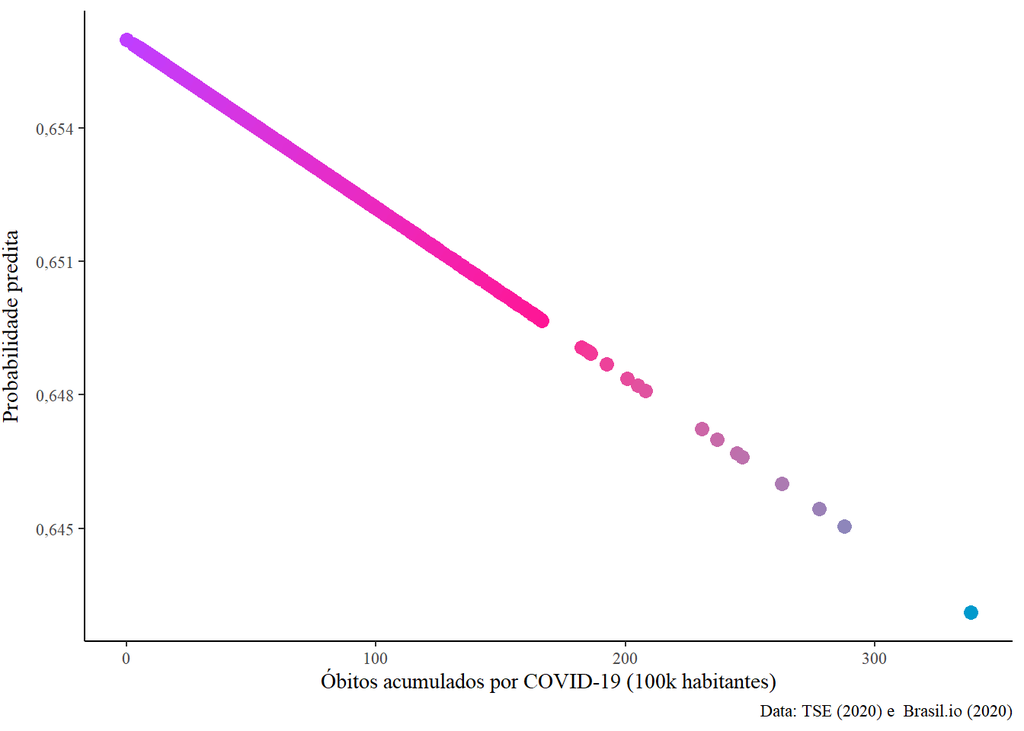

```
Resultados da relação entre reeleição e óbitos acumulados por COVID-19
```

```
##
## Call:
## glm(formula = Reeleito ~ `Óbitos Acumulados`, family = binomial(link = "logit"),
##     data = base)
##
## Deviance Residuals:
##    Min      1Q  Median      3Q     Max
## -1,461  -1,456   0,919   0,921   0,940
##
## Coefficients:
##                      Estimate Std. Error z value Pr(>|z|)
## (Intercept)          0,645433   0,057121   11,30   <2e-16 ***
## `Óbitos Acumulados` -0,000167   0,000990   -0,17     0,87
## ---
## Signif. codes:  0 '***' 0,001 '**' 0,01 '*' 0,05 '.' 0,1 ' ' 1
##
## (Dispersion parameter for binomial family taken to be 1)
##
##     Null deviance: 4144,3  on 3213  degrees of freedom
## Residual deviance: 4144,3  on 3212  degrees of freedom
## AIC: 4148
##
## Number of Fisher Scoring iterations: 4
```

Nesse modelo bem simples, o gráfico nos mostra uma discreta relação negativa entre as duas variáveis. Ou seja, quanto mais óbitos, menor a probabilidade de sucesso na reeleição.

Por outro lado, a tabela nos mostra de fato o tamanho dessa relação e o quanto ela é irrisória e estatisticamente não significante. Assim, não podemos afirmar que o número de mortes por COVID-19 é capaz de influenciar a reeleição dos candidatos ao cargo de prefeito nas eleições de 2020.

*E para você, qual variável relacionada a pandemia do COVID-19, poderia influenciar a reeleição dos candidatos a prefeito(a)?*